# BR-KLASSIK

### Wer spritzt denn da mit Blut?

[figure not shown]

Bühnenbildner Aleksandar Denic hatte eine riesige Spielfläche frei geräumt, das waren locker dreißig, vierzig Meter von der Rampe bis zur Brandmauer. Rechts und links von diesem dunklen Parcours glimmten Lichter, so dass es aussah wie eine nächtliche Landebahn - und tatsächlich setzten hier ja jede Menge Assoziationen auf. Wie bei Castorf-Exerzitien üblich, verließen einige Zuschauer vorzeitig den Corona-bedingt ohnehin sehr locker besetzten Saal, aber von den übrigen gab es durchaus freundlichen Beifall, und zwar völlig zurecht.

### Lust an der höheren Satire

Nach einem etwas zähen Auftakt ging es wirklich "molto agitato" zu, recht lebhaft, vor allem bei Kurt Weills "Sieben Todsünden", die ja allesamt in amerikanischen Großstädten von Memphis über Los Angeles bis Baltimore vorgeführt werden. Und wohl aus Lust an der höheren Satire begann Castorf den Abend mit einem Ausschnitt aus Händels Oratorium "Salomo", genauer gesagt mit der Ankunft der Königin von Saba, derselben Musik, die damals lief, als bei der Eröffnung der Olympischen Spiele in London 2012 James Bond in einer Filmeinspielung auf die Queen traf. Ob das repräsentative Barock-Stück in England noch politisch korrekt ist? [Um "Rule Britannia" gibt's ja wegen Nationalismus-Verdacht gerade mächtig Furore](https://www.br-klassik.de/aktuell/news-kritik/last-night-proms-bbc-rule-britannia-kritik-cancel-culture-100.html). Ist doch belebend, wenn die vermeintlich eherne Tradition ihren Bewahrern um die Ohren fliegt!

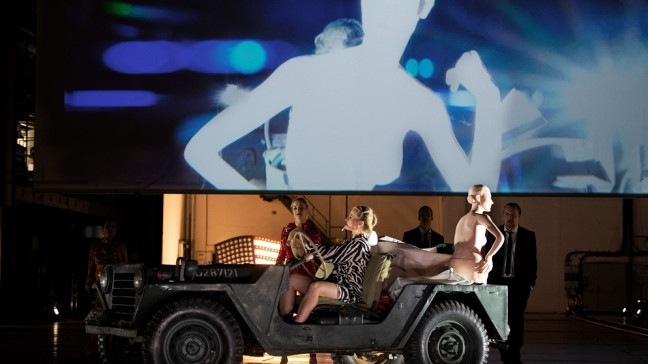

Bildquelle: Monika Rittershaus/Hamburgische Staatsoper Dirigent Kent Nagano hätte besonders die barocken Passagen (Händels "Aci, Galatea e Polifemo", 1708) deutlich schwungvoller nehmen können, war bei Kurt Weill auch etwas zu passiv, dafür gelangen ihm Györgi Ligetis lautmalerische "Neue Abenteuer" ("Nouvelles Aventures", 1965) sehr überzeugend. Eine wilde Mischung, die noch mit Liedern von Johannes Brahms gewürzt wurde.

Zum Erlebnis wurde der Abend vor allem wegen der fulminant hochtourigen Sänger und Sprecher, darunter der schon oft gefeierte Bariton Georg Nigl und Tenor Matthias Klink, aber auch Valery Tscheplanowa, die als Anna in den "Todsünden" von Brecht und Weill mit furiosem Körpereinsatz loslegte. Auch alle anderen zeigten sich hoch motiviert und gaben eine lustvoll qualmende und lässig chillende Castorf-Familie mit starkem Hang zum Wahnsinn. Obwohl, der ist ja längst weltweit Methode!

Sendung: [Allegro am 7. September 2020 ab 06.05 Uhr auf BR-KLASSIK](https://www.br-klassik.de/programm/radio/ausstrahlung-2200728.html).